# Linear Regression

Ashish Toppo

Link to this project to my drive

### Dataset Link: [Medical Cost Personal Datasets](https://www.kaggle.com/mirichoi0218/insurance/version/1)

Using this data set I need to predict the cost billed by a health insurance company based on some parameters.  
**Description:**  
**age:** age of primary beneficiary  
**sex:** insurance contractor gender, female, male  
**bmi:** Body mass index, providing an understanding of body, weights that are relatively high or low relative to height, objective index of body weight (kg / m ^ 2) using the ratio of height to weight, ideally 18.5 to 24.9  
**children:** Number of children covered by health insurance / Number of dependents  
**smoker:** Smoking  
**region:** the beneficiary’s residential area in the US, northeast, southeast, southwest, northwest.  
**charges:** Individual medical costs billed by health insurance

### Reading of the dataset and importing necessary libraries

```r
library(tidyverse)
library(reshape2)
library(caTools)
library(corrplot)
library(MLmetrics)
library(ggfortify)
data_0 <- read.csv("insurance.csv", stringsAsFactors = TRUE) #converting all strings to factors
```

```r
#peeping into data
head(data_0)
```

```
##   age    sex    bmi children smoker    region   charges
## 1  19 female 27.900        0    yes southwest 16884.924
## 2  18   male 33.770        1     no southeast  1725.552
## 3  28   male 33.000        3     no southeast  4449.462
## 4  33   male 22.705        0     no northwest 21984.471
## 5  32   male 28.880        0     no northwest  3866.855
## 6  31 female 25.740        0     no southeast  3756.622
```

```r
# dimension of the dataset
dim(data_0)
```

```
## [1] 1338    7
```

```r
# structure of the dataset
str(data_0)
```

```
## 'data.frame':    1338 obs. of  7 variables:
##  $ age     : int  19 18 28 33 32 31 46 37 37 60 ...
##  $ sex     : Factor w/ 2 levels "female","male": 1 2 2 2 2 1 1 1 2 1 ...
##  $ bmi     : num  27.9 33.8 33 22.7 28.9 ...
##  $ children: int  0 1 3 0 0 0 1 3 2 0 ...
##  $ smoker  : Factor w/ 2 levels "no","yes": 2 1 1 1 1 1 1 1 1 1 ...
##  $ region  : Factor w/ 4 levels "northeast","northwest",..: 4 3 3 2 2 3 3 2 1 2 ...
##  $ charges : num  16885 1726 4449 21984 3867 ...
```

**Factors:** are the data objects which are used to categorize the data and store it as levels.  
I’ll be converting variables to factors if there comes a need to. For now I’ll be jumping into analysis.

### Summary Statistics

```r
summary(data_0)
```

```
##       age            sex           bmi           children     smoker
##  Min.   :18.00   female:662   Min.   :15.96   Min.   :0.000   no :1064
##  1st Qu.:27.00   male  :676   1st Qu.:26.30   1st Qu.:0.000   yes: 274
##  Median :39.00                Median :30.40   Median :1.000
##  Mean   :39.21                Mean   :30.66   Mean   :1.095
##  3rd Qu.:51.00                3rd Qu.:34.69   3rd Qu.:2.000
##  Max.   :64.00                Max.   :53.13   Max.   :5.000
##        region       charges
##  northeast:324   Min.   : 1122
##  northwest:325   1st Qu.: 4740
##  southeast:364   Median : 9382
##  southwest:325   Mean   :13270
##                  3rd Qu.:16640
##                  Max.   :63770
```

### Missng Values and their proportions by columns

```r
null_cols <- colSums(is.na(data_0))/nrow(data_0)*100
null_cols[null_cols!=0]
```

```
## named numeric(0)
```

We are lucky to not have any missing data in any of the columns.

### Looking for outliers in numeric columns and their analysis

```r
box_dist <- function(x,y){
  #` a custom function to plot histogram and box plot for a column
  print(x %>% ggplot(aes_string(y))+geom_boxplot())
  print(x %>% ggplot(aes_string(y))+geom_histogram(fill="orange", color="black"))
}
```

### For age

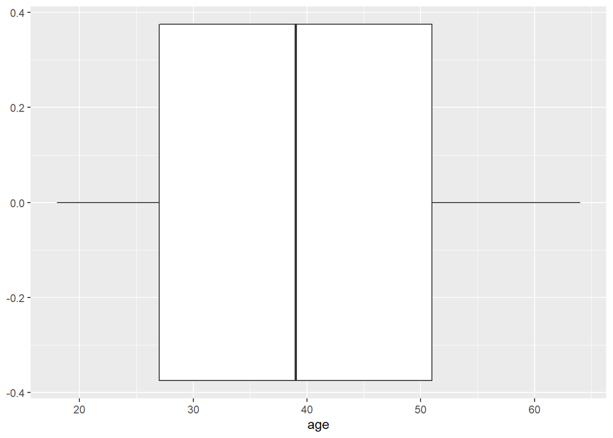

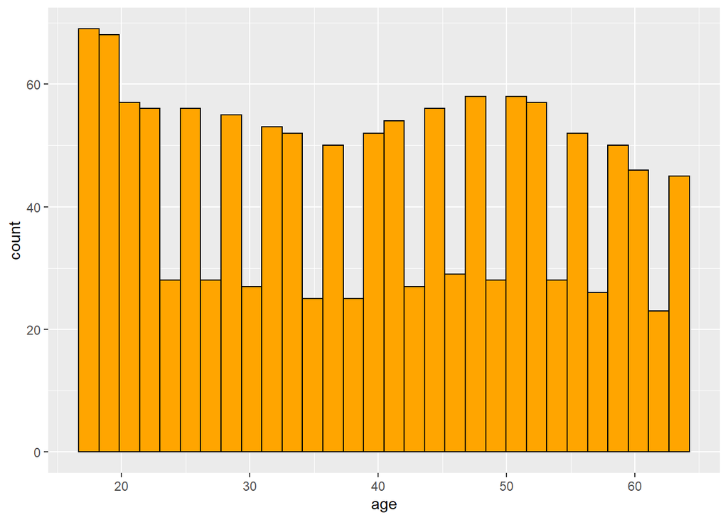

```r
box_dist(data_0,"age")
```

**Observations**  
1. There aren’t any outliers.  
2. Looking at the distribution we can see that:  
* Highest number of insurances was purchased by people below the age of 20, even though people don’t buy insurances at such early ages so its worth checking which gender or region has such customers.  
* We can see a **WAVY** curve which reduces at ages near 35 and near 64, which can be thought as people normally marry in early thirties and people becoming health concerned at the early fifties.  
* There isn’t any other pattern seen with regards to age.

### Doing some Analysis on age

**Q** *Linear relation b/w age and charges*

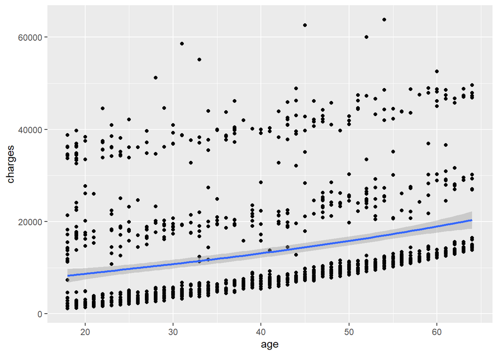

```
##       charges
## age 0.2990082
```

```r
linearity <- function(df,c1,c2){
  #`a function to produce scatter plot and checking correlation b/w independent and dependent
  print(df %>% ggplot(aes_string(c1,c2))+geom_point()+geom_smooth())
  print(cor(df[c1],df[c2]))
}
linearity(data_0,"age","charges")
```

**Observations**  
1. There is a linear relation b/w age(independent) and charges(dependent) but weak correlation.

**Q** *Is gender a factor for getting life insurance and does age matters*

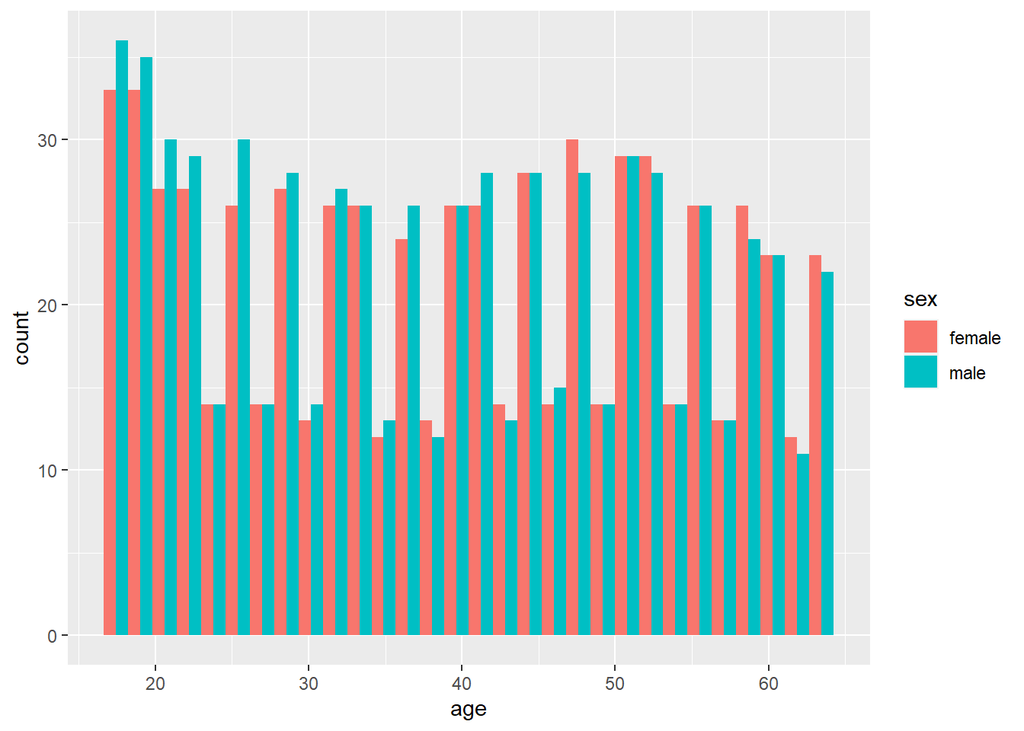

```r
data_0 %>% ggplot(aes(age))+geom_histogram(aes(fill=sex),position = "dodge")
```

**Observations**  
1. Men tend to buy insurance at early ages(age <30).  
2. There is an increase in no. of women choosing insurance after age 40 compared to men. It will be worth checking if regions or bmi play a role in this trend.

**Q** *Looking why there is increase in no. of women getting insured after age 40*

```r
#checking if a particular region causes this rise
data_0 %>% filter(age>40) %>%  group_by(region) %>% summarise(table = table(sex))
```

```
## # A tibble: 8 x 2
## # Groups:   region [4]
##   region    table
##   <fct>     <table>
## 1 northeast 79
## 2 northeast 76
## 3 northwest 80
## 4 northwest 73
## 5 southeast 83
## 6 southeast 89
## 7 southwest 79
## 8 southwest 78
```

**Observations**  
The above table might be confusing but it’s simple as sex(factor) has got levels female, male and first is female.  
1. So every odd index for each region, counts the no. of females with age>40.  
2. So it seems that region doesn’t plays a role in this as regions has got (79,80,83,79) which is almost in similar proportion.

```r
# lets check if bmi is cause for this increase
data_1 <- data_0 #to not tamper original data
# converting bmi's to categories
data_1$bmi <- cut(data_1$bmi, breaks = c(-Inf,24.9,30,Inf), labels = c("healthy","overweight","obese"))
data_1 %>% filter(age<40) %>% group_by(bmi) %>% summarize(table=table(sex))
```

```
## # A tibble: 6 x 2
## # Groups:   bmi [3]
##   bmi        table
##   <fct>      <table>
## 1 healthy     81
## 2 healthy     65
## 3 overweight  95
## 4 overweight 106
## 5 obese      152
## 6 obese      175
```

**Q** *Are age and charges correlated*

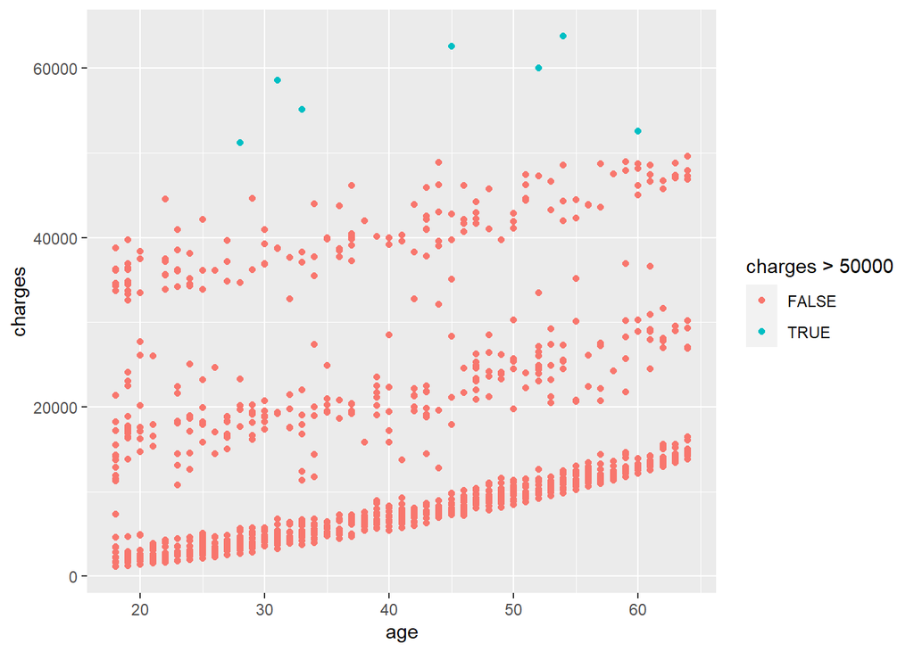

```r
data_0 %>% ggplot(aes(age,charges)) + geom_point(aes(color=charges>50000))
```

**Observations**  
1. There is a linear trend which can be observed so age influences the charges as when people age they are prone to getting ill.  
2. There are few patients which are charged more than 50000 for some people b/w 25 to 60, maybe the got some serious illness. A look in BMI and checking if that person is a smoker might get us some insight.

**Q** *Does BMI related to age and smoking*

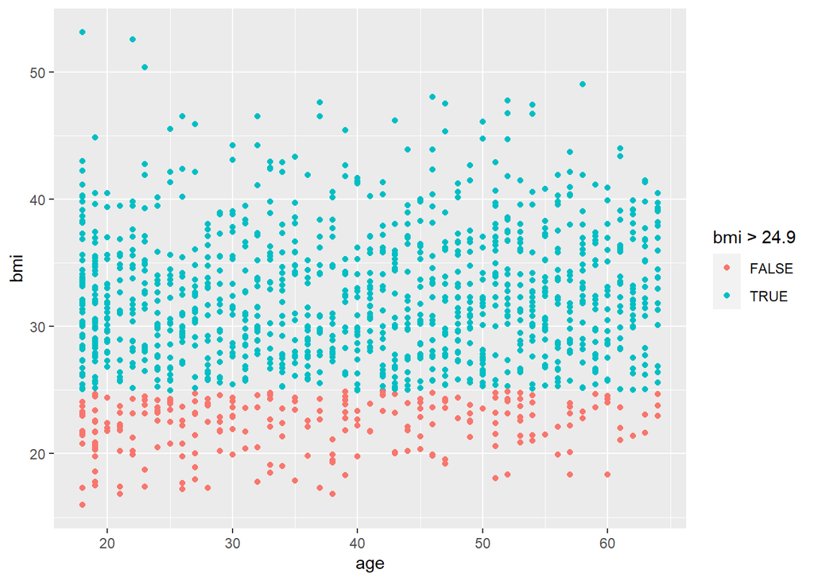

```r
data_0 %>% ggplot(aes(age,bmi)) + geom_point(aes(color=bmi>24.9))# bmi <24.9 is overweight <30 is obese
```

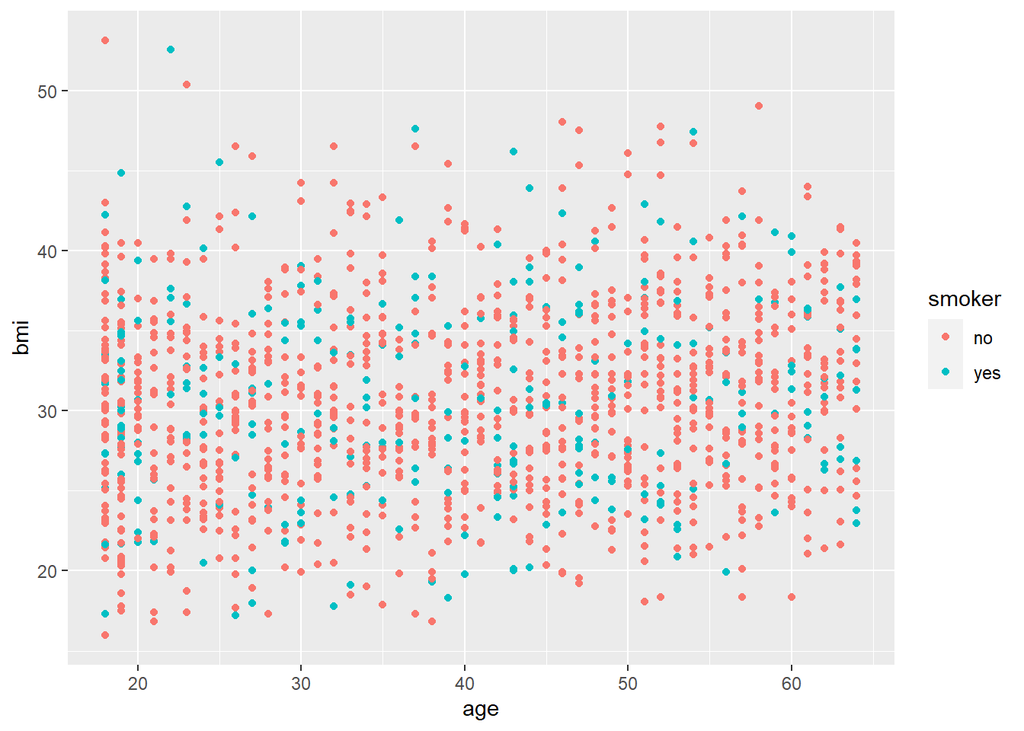

```r
data_0 %>% ggplot(aes(age,bmi)) + geom_point(aes(color=smoker))
```

**Q** *People from which region and ages choose to get insured*

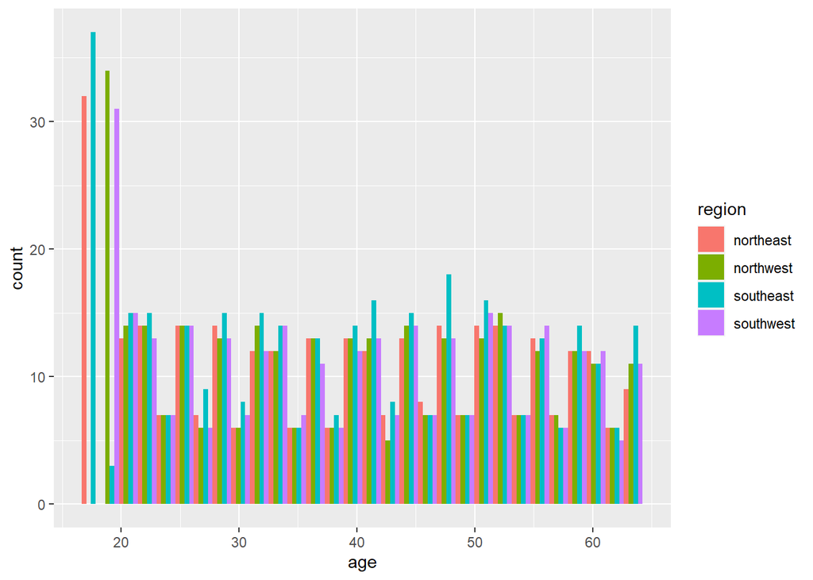

```r
data_0 %>% ggplot(aes(age))+geom_histogram(aes(fill=region),position = "dodge")
```

### For bmi

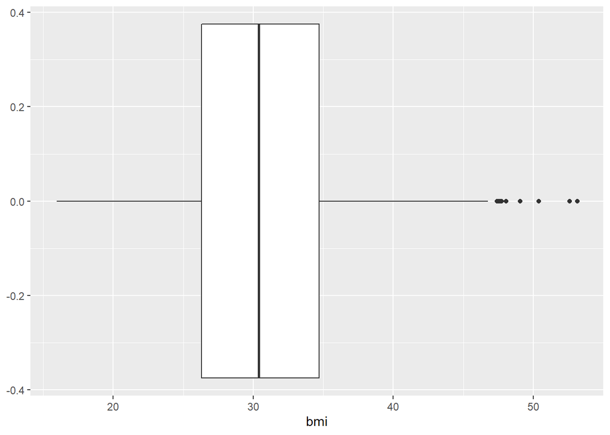

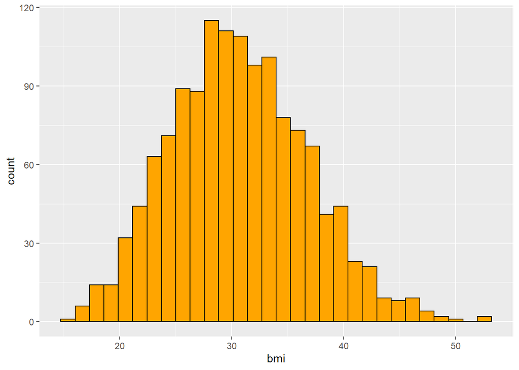

```r
box_dist(data_0,"bmi")
```

**Observations**  
There are outliers as observed previously in (age vs bmi). Let’s first check if bmi is related to cost of insurance.

### Doing some Analysis on bmi

**Q** *Linear relation b/w bmi and charges*

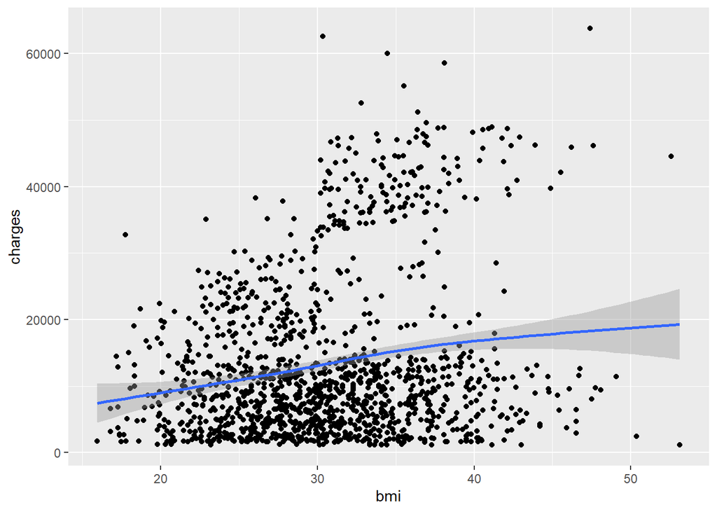

```
##      charges
## bmi 0.198341
```

```r
linearity(data_0,"bmi","charges")
```

**Observations**  
1. There is a linear relationship(almost) b/w bmi(independent) and charges(dependent) but too weak correlation(<.2).

**Q** *Are bmi and charges related and does region affects this relationship*

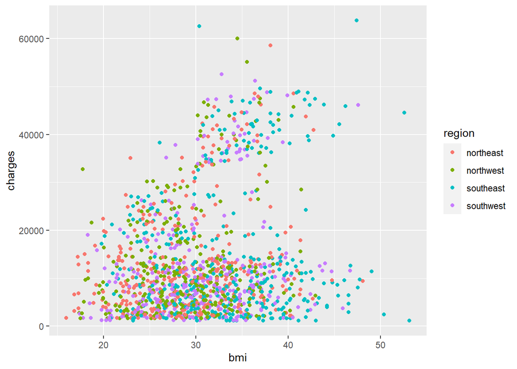

```r
data_0 %>% ggplot(aes(bmi,charges))+geom_point(aes(color=region)) #outliers seem to be above bmi of 47 in above boxplot
```

```r
# removing outliers in bmi
data_2 <- data_0 %>% filter(!bmi>47) #not tampering original data
# no. of rows removed
nrow(data_0)-nrow(data_2)
```

```
## [1] 9
```

**Q** *What type of bmi’s does each region have*

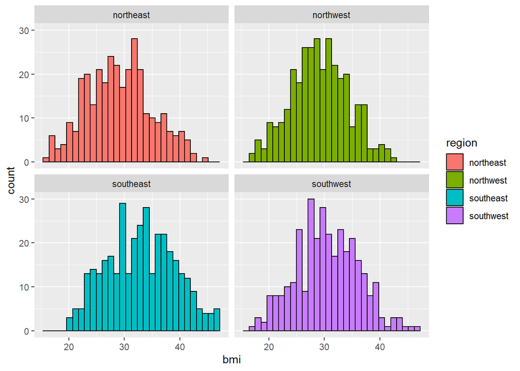

```r
data_2 %>% ggplot(aes(bmi))+geom_histogram(aes(fill=region),color="black")+facet_wrap(~region)
```

**Observations**  
1. Southeast region doesn’t have underweight people(bmi<18.5).  
2. All the regions have high no. of obese people.

### For Children

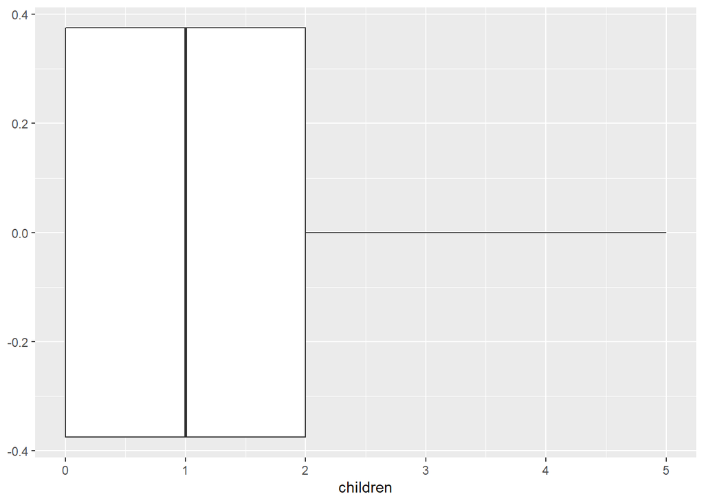

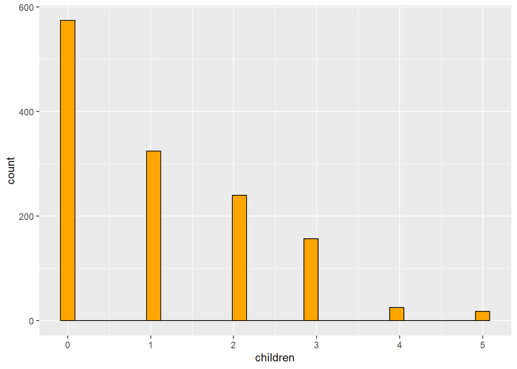

```r
box_dist(data_0,"children")
```

**Observations**  
1. No outliers, hence no need for removal or transformation(s).

### Some analysis

**Q** *No. of children per region*

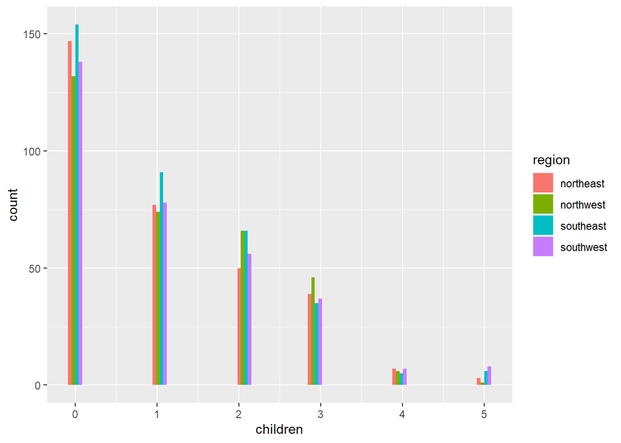

```r
data_2 %>% ggplot(aes(children))+geom_histogram(aes(fill=region),position = "dodge")
```

**Q** *How much of charges does each region make*

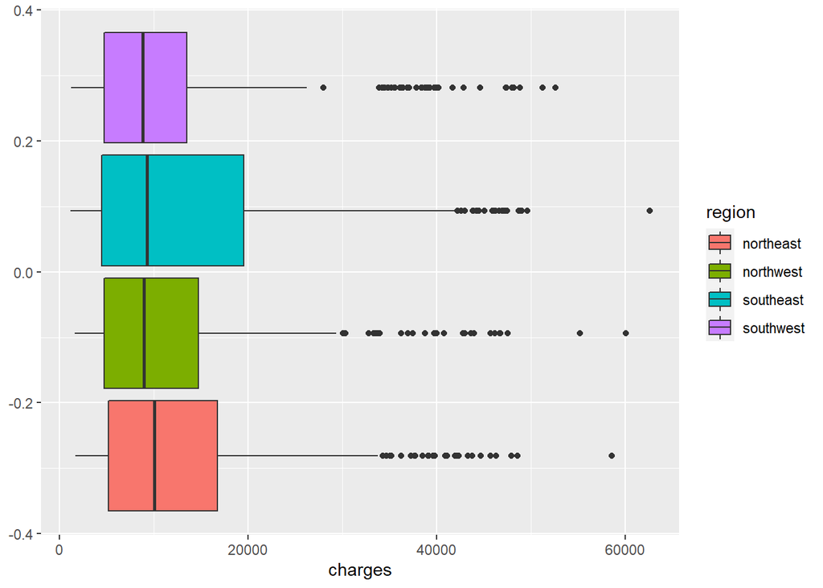

```r
data_2 %>% ggplot(aes(charges))+geom_boxplot(aes(fill=region))
```

**Observations**  
1. Only Southwest region has not crossed the charge of 55000.  
2. Southeast region is the most paying as the range of Q3 and Q2 is high compared to others.  
3. There are many outliers in other regions compared to southeast region.

**Q** *Which region has most no. of smokers based on gender*

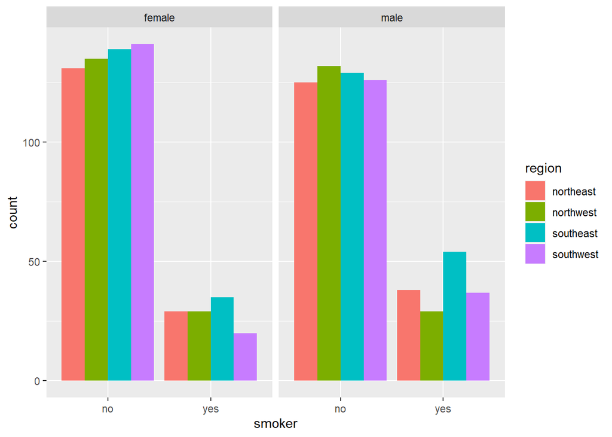

```r
data_2 %>% ggplot(aes(smoker))+geom_bar(aes(fill=region),position = "dodge")+facet_wrap(~sex)
```

**Observations**  
1. Southeast region has the maximum people who are smokers followed by northeast region(both male and female).  
2. Northwest has least no. of male smokers and southwest has least no. of female smokers.

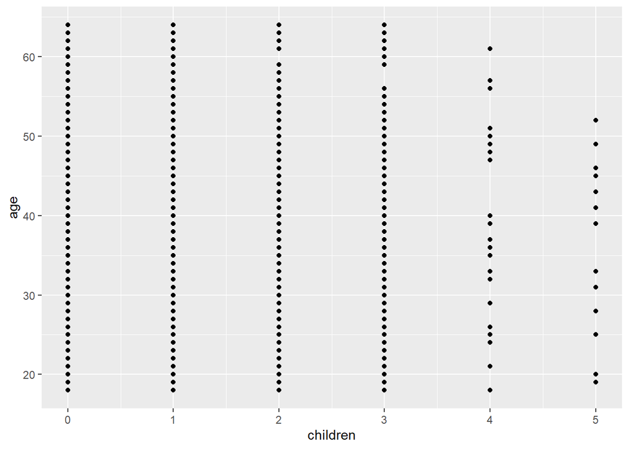

```
##               age
## children 0.042469
```

```r
linearity(data_0,"children","age")
```

### Checking for collinearity

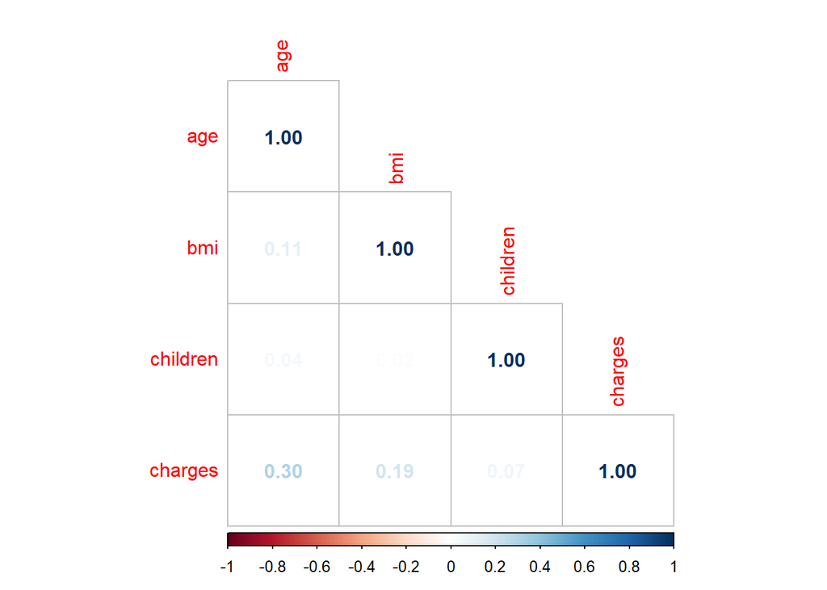

```r
# getting the indexes of all numerical columns
num_idx <- which(!grepl("factor|character",sapply(data_2,class)))
M <- cor(data_2[num_idx])
corrplot(M,method = "num",type = "lower")
```

**Observations**  
1. There is weak correlation(s) among independent variables. So no need to remove any columns or do any step wise relation check for variables.

### Splitting and Modelling

```r
sample <- sample.split(data_2$charges,.7)
train <- data_2 %>% filter(sample==TRUE)
test <- data_2 %>% filter(sample==FALSE)
#verifying the dimensions
dim(test) #test set
```

```
## [1] 399   7
```

```r
dim(train) #train set
```

```
## [1] 930   7
```

### Model

```r
model <- lm(charges~age+bmi,train)
predict_train <- predict(model,train[c("age","bmi")])
predict_test <- predict(model,test[c("age","bmi")])
```

### Evaluating the performance of the model

```r
summary(model)
```

```
##
## Call:
## lm(formula = charges ~ age + bmi, data = train)
##
## Residuals:
##    Min     1Q Median     3Q    Max
## -12380  -7051  -5241   7616  47992
##
## Coefficients:
##             Estimate Std. Error t value Pr(>|t|)
## (Intercept) -6132.57    2104.73  -2.914  0.00366 **
## age           240.56      26.78   8.981  < 2e-16 ***
## bmi           326.35      62.55   5.217 2.24e-07 ***
## ---
## Signif. codes:  0 '***' 0.001 '**' 0.01 '*' 0.05 '.' 0.1 ' ' 1
##
## Residual standard error: 11290 on 927 degrees of freedom
## Multiple R-squared:  0.1151, Adjusted R-squared:  0.1132
## F-statistic: 60.27 on 2 and 927 DF,  p-value: < 2.2e-16
```

```r
# RMSE of test
RMSE(predict_test,test$charges)
```

```
## [1] 11270.29
```

```r
# RMSE of train
RMSE(predict_train,train$charges)
```

```
## [1] 11271.92
```

```r
# R2 Score
R2_Score(predict_test,test$charges)
```

```
## [1] 0.1199929
```

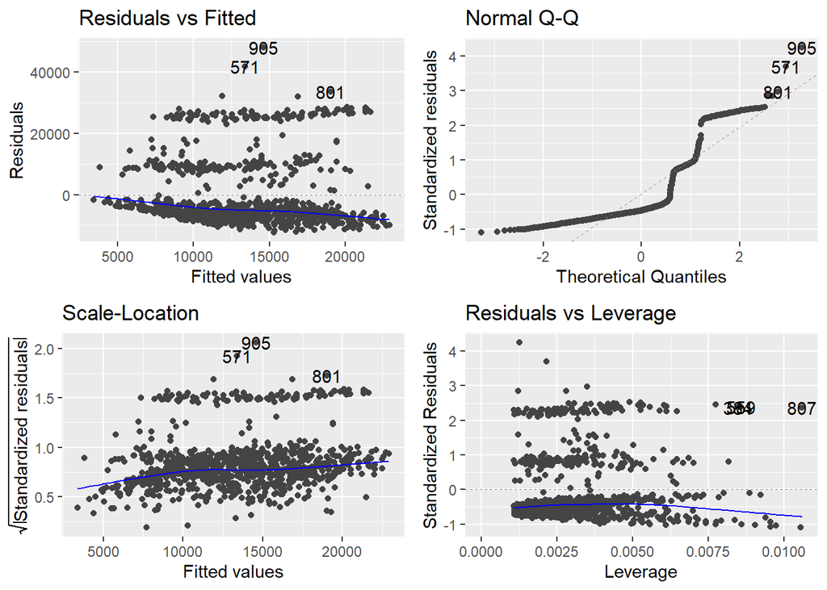

```r
library(ggfortify)
autoplot(model)
```

**Observations**  
1. Though the r-squared score is low as we see that the assumptions are not fulfilled for linear regression.  
2. While looking at the correlation b/w *each independent variable* and *the dependent variable* which we found to be very low and we didn’t consider one of the variables out of a total of 3 variables which leave us with only 2.  
3. The model would have performed better if it satisfied the linearity assumption.  
4. It’s highly unlikely to find dataset which satisfies the assumptions of the linear regression.  
5. So it’s much better to move or to check tree based models.